# Sesión 2

# Objetivo de la sesión

El ejercicio de esta sesión pretende afianzar los conocimientos y habilidades para

- Organizar y limpiar los datos
- Crear variables
- Comunicar los hallazgos

# Aplicación: evolución reciente del crecimiento económico en Colombia

Según los últimos datos del [DANE](https://www.dane.gov.co/index.php/estadisticas-por-tema/cuentas-nacionales/cuentas-nacionales-trimestrales/pib-informacion-tecnica) la economía alcanzó una tasa de crecimiento anual de 12.6% en el segundo trimestre de 2022. Este es un desempeño notable. En esta sesión queremos responder las siguientes preguntas

1. ¿Cómo se compara este crecimiento con el de periodos anteriores?
2. ¿Cómo ha sido la contribución de los componentes del gasto al crecimiento del PIB?
3. ¿Cuánto ha sido la participación de cada componente del gasto en el PIB?

# Datos

Trabajaremos con la serie trimestra del PIB por el lado del gasto a precios constantes. El archivo original publicado por el DANE lo encuentra [acá](https://www.dane.gov.co/index.php/estadisticas-por-tema/cuentas-nacionales/cuentas-nacionales-trimestrales/pib-informacion-tecnica). El archivo para trabajar lo encuentra lo puede descargar del [REPO](https://github.com/caribe-en-datos/viernes_code/blob/main/data/PIB.xlsx)

# Paso a Paso

1. Cargue los datos

```
library(readxl)
pib<-read_excel()
```

2. La tasa de crecimiento anual del PIB, con datos trimestrales, la calculamos como

$$g_Y=\dfrac{Y_t}{Y_{t-4}}-1$$

```
library(dplyr)
pib<-mutate()
```

3. Graficamos la tasa de crecimiento del PIB

```
library(ggplot2)
ggplot(pib,aes(x=,y=))+geom_¿?()
```

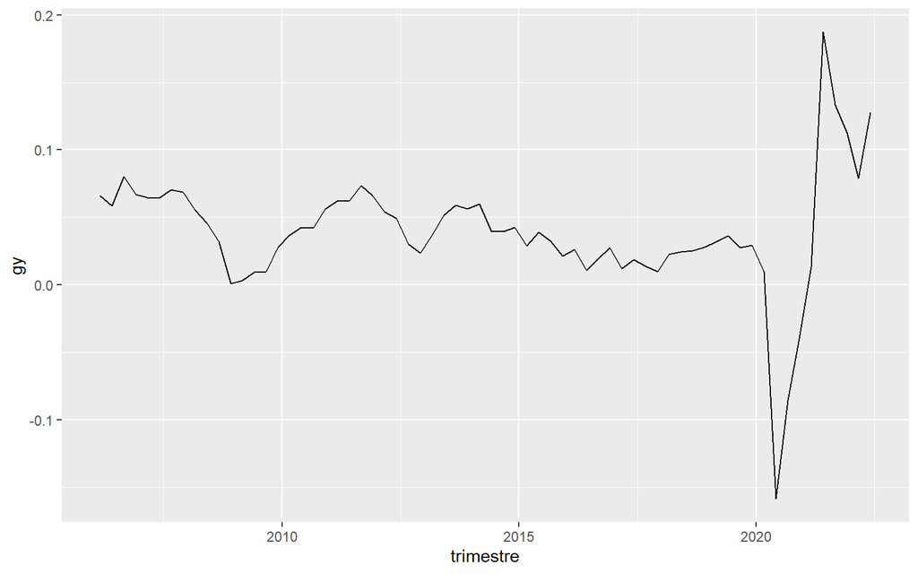

La gráfica la puede editar para colocarle título, nombres de los ejes, fuente de los datos, cambiar colores, fondo, etc.

Con la gráfica anterior puede responder la pregunta 1. Escriba su respuesta

4. Para la pregunta 2 debemos calcular la contribución de cada componente del gasto al crecimiento del PIB. Para ello, debemos tener presente la identidad contable del PIB por el lado del gasto

$$Y_t=C_t+I_t+G_t+X_t-M_t$$

Es decir, que la tasa de crecimiento del PIB es la suma ponderada de las tasas de crecimiento de cada componente del gasto

5. Calcule la participación de cada componente del gasto en el PIB

```
# FORMA 1
pib$wc<-pib$C/pib$Y

# FORMA 2
pib<-pib%>%mutate(wc=C/Y)
```

6. Calcule la contribución de cada componente $\dfrac{C_{t-4}}{Y_{t-4}}\dfrac{C_{t}-C_{t-4}}{C_{t-4}}$
5. Graficar las contribuciones de cada componente a lo largo del tiempo

Para hacer este gráfico necesitamos cambiar la estructura de nuestros datos, de formato ancho (wide) a largo (long). Esto lo hacemos con la función *pivot_longer* del paquete **Tydiverse**

```r
piblong<-pib%>%na.omit()%>%select(trimestre,gy,wgc,wgi,wgg,wgx,wgm)
piblong<-pivot_longer(piblong,!c(trimestre,gy), names_to="comp",values_to="value")
```

Haremos un gráfico de barras, donde los componentes de gasto están apilados (*stacked*) por trimestre. Complete el código siguiente

```
ggplot(,aes(x=,y=,fill=comp))+geom_bar(stat="identity")+geom_line(aes(y=gy),size=1)
```

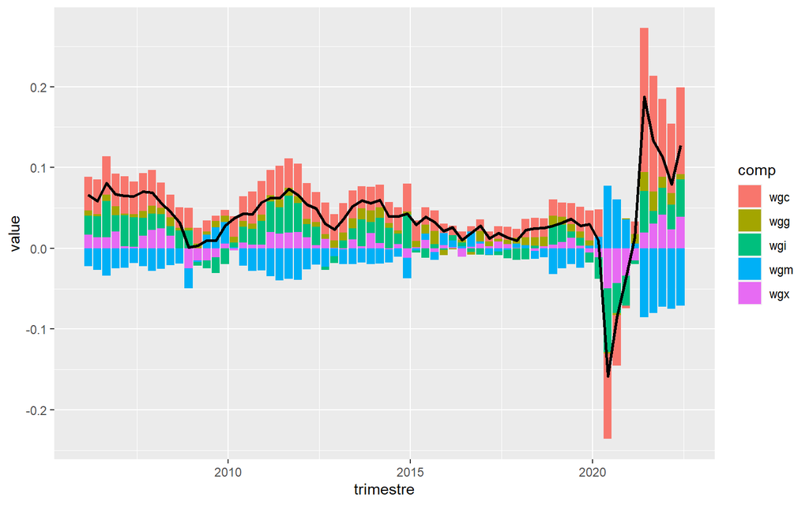

- ¿Qué modificaciones estéticas le haría al gráfico?
- Interprete su hallazgo